# Análise exploratória

Durante a observação dos dados, percebemos que uma pequena parcela dos cliques resultará em um download, bem como existem mais de 180 milhões de registros disponíveis para análise.

Faremos uma observação mais específica sobre todas as ocorrências de downloads. Para isso, vamos percorrer todo o arquivo com dados de treino e selecionar apenas as ocorrências que resultaram em download:

```r
require(data.table)
require(ggplot2)
require(lubridate)
require(scales)

#Parâmetros para leitura do arquivo
row_index <- 0
sample_size <- 2000000
train_length <- 184903891
is_attributed_true <- list()
```

```r
#Percorremos todo o dataset de treino
while (row_index < train_length) {
  #Fazemos a leitura a cada 'sample_size' linhas
  train_sample <- fread('../input/train.csv', nrows = sample_size, skip = row_index,
                        col.names = c('ip', 'app', 'device', 'os',
                                      'channel', 'click_time', 'attributed_time',
                                      'is_attributed'))

  #Apenas os registros que resultaram em download são selecionados
  is_attributed_true <- append(is_attributed_true, list(train_sample[is_attributed > 0]))
  row_index <- row_index + sample_size
}
#Agrupando todos os registros de download em um único dataset
download_info <- rbindlist(is_attributed_true)

#Gravando os registros de download para utilização posterior
fwrite(download_info, '../output/download_info.csv')

#Removendo variáveis que não serão utilizadas
rm(row_index, sample_size, train_length, is_attributed_true, train_sample)
invisible(gc())
```

```r
print(download_info)
```

```
##             ip app device os channel          click_time
##      1: 204158  35      1 13      21 2017-11-06 15:41:07
##      2:  29692   9      1 22     215 2017-11-06 16:00:02
##      3:  64516  35      1 13      21 2017-11-06 16:00:02
##      4: 172429  35      1 46     274 2017-11-06 16:00:03
##      5: 199085  35      1 13     274 2017-11-06 16:00:04
##     ---
## 456841: 313982  10      1 27     113 2017-11-09 15:59:21
## 456842: 331467   5      1 47     113 2017-11-09 15:59:21
## 456843:  29789  45      1 32     419 2017-11-09 15:59:26
## 456844: 308776  10      1 11     113 2017-11-09 15:59:26
## 456845: 176331   9      1 19     127 2017-11-09 15:59:33
##             attributed_time is_attributed
##      1: 2017-11-07 08:17:19             1
##      2: 2017-11-07 10:05:22             1
##      3: 2017-11-06 23:40:50             1
##      4: 2017-11-07 00:55:29             1
##      5: 2017-11-06 23:04:54             1
##     ---
## 456841: 2017-11-09 15:59:53             1
## 456842: 2017-11-09 15:59:26             1
## 456843: 2017-11-09 15:59:42             1
## 456844: 2017-11-09 15:59:58             1
## 456845: 2017-11-09 15:59:59             1
```

Identificamos 456.845 ocorrências de downloads, o que representa aproximadamente 0.24% do total de cliques.

```r
unique_values <- data.table(unique_ip = length(unique(download_info$ip)),
                            unique_app = length(unique(download_info$app)),
                            unique_device = length(unique(download_info$device)),
                            unique_os = length(unique(download_info$os)),
                            unique_channel = length(unique(download_info$channel)))
print(unique_values)
```

```
##    unique_ip unique_app unique_device unique_os unique_channel
## 1:    245038        226          1869       116            174
```

Ao todo, identificamos 226 aplicativos anunciados por 174 canais de comunicação

## IP de origem

Essa variável representa o endereço IP de origem do registro, entretanto, não sabemos se estes IPs representam usuários individuais, roteadores, proxies ou outros dispositivos agregadores de múltiplos usuários.

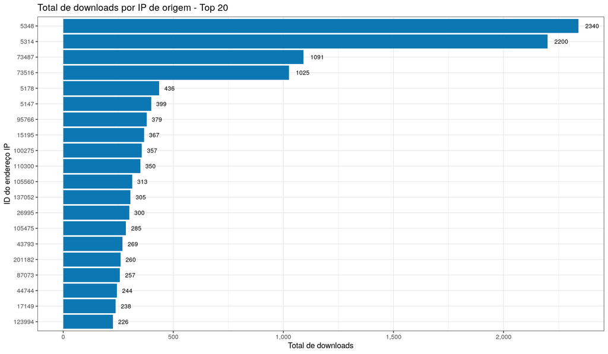

```r
total_clicks <- nrow(download_info)
ip_downloads <- download_info[, .(downloads = .N), by = ip]
ip_downloads[, ip := as.factor(ip)]

ggplot(data = ip_downloads[order(-downloads)][1:20]) +
  geom_bar(mapping = aes(x = reorder(ip, downloads), y = downloads),
           fill = '#0b78b3', stat = 'identity', position = 'dodge') +
  geom_text(mapping = aes(x = reorder(ip, downloads),
                          y = downloads, label = downloads),
           hjust = -0.5, size = 3, position = position_dodge(width = 1),
           inherit.aes = T) +
  scale_y_continuous(labels = comma) + coord_flip() +
  ylab('Total de downloads') + xlab('ID do endereço IP') + theme_bw() +
  ggtitle('Total de downloads por IP de origem - Top 20')
```

Percebemos que alguns IPs realizaram uma quantidade aparentemente excessiva de downloads, mas não conseguimos identificar apenas por este gráfico se este é um comportamento esperado.

Vamos calcular e observar os quantis de downloads por IP:

```r
#Calculamos os quantis de downloads por IP
ip_quantiles <- quantile(ip_downloads$downloads, seq(0.6, 1, 0.05))

#Colocamos os quantis calculados em um data frame
print(data.frame(quantile = names(ip_quantiles),
                 downloads = ip_quantiles))
```

```
##      quantile downloads
## 60%       60%         1
## 65%       65%         1
## 70%       70%         1
## 75%       75%         1
## 80%       80%         2
## 85%       85%         2
## 90%       90%         3
## 95%       95%         5
## 100%     100%      2340
```

Pelo menos 75% dos IPs identificados realizaram um único download após o clique. Entre os quantis 80% e 95%, percebemos que os usuários realizaram de 2 a 5 downloads. Os registros apresentados no gráfico anterior representam valores entre os quantis 95 e 100.

Observar os quantis nos auxiliou a perceber que o comportamento esperado pelo usuário é realizar apenas 1 download. Entretanto, existem usuários que realizaram múltiplos downloads de um ou mais aplicativos. Ambos comportamentos são desejáveis.

Faremos mais uma análise nos IPs com maior quantidade de downloads registrados. Vamos identificar quantos aplicativos distintos foram baixados:

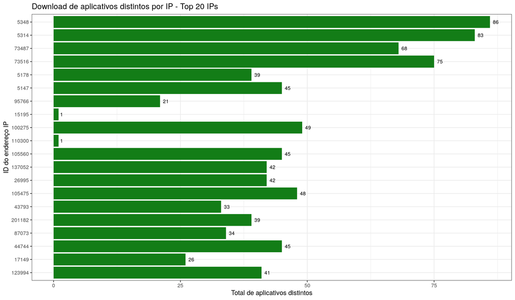

```r
#Selecionamos os 20 IPs que mais realizaram downloads
most_ip_downloads <- ip_downloads[order(-downloads), ip][1:20]

#Identificamos a quantidade de downloads por aplicativo dos IPs mais predominantes
ip_app_downloads <- download_info[ip %in% most_ip_downloads, .(downloads = .N), by = .(ip, app)]
most_ip_downloads <- ip_app_downloads[, .(app_count = .N, total_downloads = sum(downloads)), by = ip]

ggplot(data = most_ip_downloads[order(-total_downloads)][1:20]) +
  geom_bar(mapping = aes(x = reorder(ip, total_downloads), y = app_count),
           fill = '#137d17', stat = 'identity', position = 'dodge') +
  geom_text(mapping = aes(x = reorder(ip, app_count),
                          y = app_count, label = app_count),
           hjust = -0.5, size = 3, position = position_dodge(width = 1),
           inherit.aes = T) +
  coord_flip() + ylab('Total de aplicativos distintos') + xlab('ID do endereço IP') +
  theme_bw() + ggtitle('Download de aplicativos distintos por IP - Top 20 IPs')
```

Mantivemos a mesma ordem do primeiro gráfico, em que apresentamos o total de downloads por IP. Os registros 15195 e 110300 chamam a atenção por representarem downloads de um único aplicativo: ambos efetuaram 367 e 350 downloads, respectivamente, de um único aplicativo!

As visualizações de downloads por IPs são interessantes para tentarmos entender o comportamento dos usuários, entretanto não foi possível sanar as dúvidas iniciais (cada IP é um usuário distinto ou um grupo de usuários?).

## Aplicativos

Cada aplicativo tem suas próprias características e público-alvo. Não temos muitas informações a respeito de cada app, mas podemos identificar quais são os mais procurados a partir do total de downloads realizados.

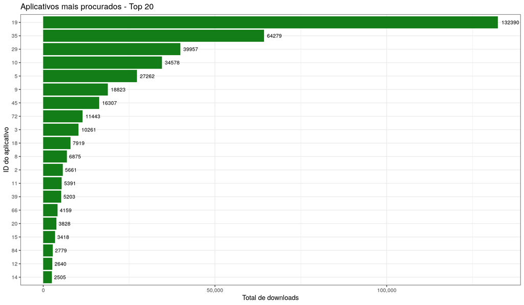

```r
app_downloads <- download_info[, .(downloads = .N,
                                   prop_downloads = .N/total_clicks), by = app]
app_downloads[, app := as.factor(app)]

ggplot(data = app_downloads[order(-downloads)][1:20]) +
  geom_bar(mapping = aes(x = reorder(app, downloads), y = downloads),
           fill = '#137d17', stat = 'identity', position = 'dodge') +
  geom_text(mapping = aes(x = reorder(app, downloads),
                          y = downloads, label = downloads),
           hjust = -0.2, size = 3, position = position_dodge(width = 1),
           inherit.aes = T) +
  scale_y_continuous(labels = comma) + coord_flip() +
  ylab('Total de downloads') + xlab('ID do aplicativo') +
  theme_bw() + ggtitle('Aplicativos mais procurados - Top 20')
```

Neste conjunto de dados, o app 19 é o aplicativo mais procurado pelos usuários. Portanto, cliques neste aplicativo possuem maior probabilidade de resultar em download do aplicativo. Para representar este comportamento durante a criação do algoritmo de machine learning, será calculada a média de downloads e cliques por aplicativo.

Com os dados disponíveis neste dataset, também podemos elaborar um filtro colaborativo para apresentar recomendações baseado em downloads dos demais usuários:

```r
#Usuários que baixaram o app 19
app_19_users <- download_info[app == 19, unique(ip)]

#Também baixaram estes apps
app_19_also_downloaded <- download_info[ip %in% app_19_users & app != 19]

#Calculamos o total de usuários similares e a proporção de downloads
total_similar_downloads <- nrow(app_19_also_downloaded)
app_19_also_downloaded <- app_19_also_downloaded[, .(prop_downloads = .N / total_similar_downloads), by = app]

print(app_19_also_downloaded[order(-prop_downloads)][1:10])
```

```
##     app prop_downloads
##  1:  35     0.32177453
##  2:  29     0.11659670
##  3:   9     0.08904458
##  4:  10     0.04350908
##  5:   8     0.04145539
##  6:  18     0.03786598
##  7:  11     0.02909692
##  8:   3     0.02868800
##  9:  20     0.02651618
## 10:   2     0.02149101
```

Manter um sistema de recomendações é uma ideia interessante para sugerir outros downloads para cada usuário, contudo, não vamos explorar essa abordagem neste trabalho.

## Dispositivos

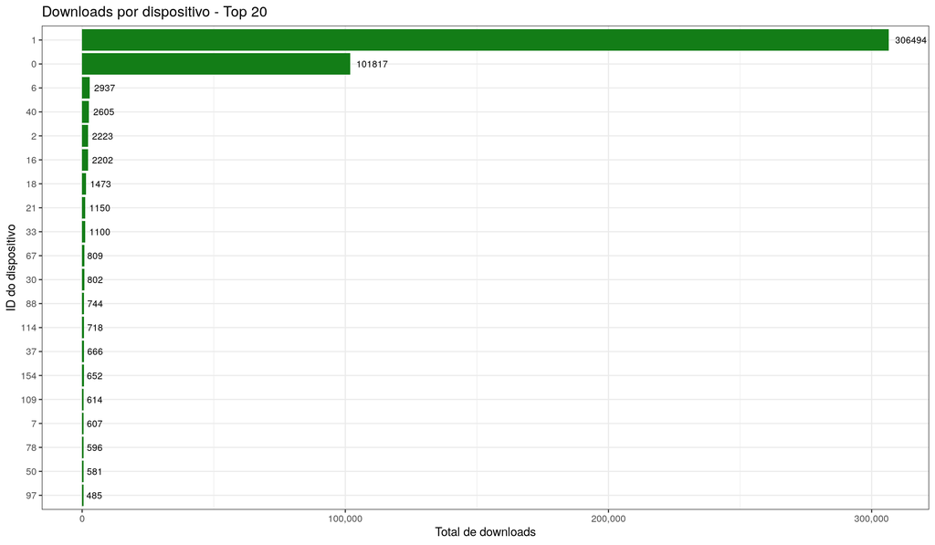

```r
device_downloads <- download_info[, .(downloads = .N), by = device]
device_downloads[, device := as.factor(device)]

ggplot(data = device_downloads[order(-downloads)][1:20]) +
  geom_bar(mapping = aes(x = reorder(device, downloads), y = downloads),
           fill = '#137d17', stat = 'identity', position = 'dodge') +
  geom_text(mapping = aes(x = reorder(device, downloads),
                          y = downloads, label = downloads),
           hjust = -0.2, size = 3, position = position_dodge(width = 1),
           inherit.aes = T) +
  scale_y_continuous(labels = comma) + coord_flip() +
  ylab('Total de downloads') + xlab('ID do dispositivo') +
  theme_bw() + ggtitle('Downloads por dispositivo - Top 20')
```

Os dispositivos 1 e 0 representam a grande maioria dos aparelhos utilizados pelos usuários que efetuaram download, sugerindo duas hipóteses:

- Existe uma grande preferência dos usuários pelos dispositivos 1 e 0;
- A maioria dos aplicativos anunciados funcionam apenas nos dispositivos 1 e 0.

## Sistema operacional

Essa variável está relacionada com o dispositivo do usuário: cada dispositivo utiliza uma versão específica de um sistema operacional.

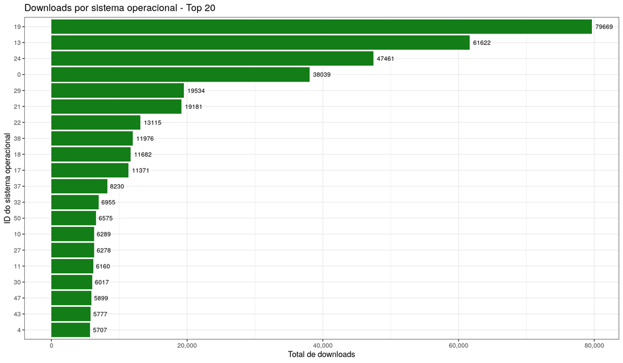

```r
os_downloads <- download_info[, .(downloads = .N), by = os]
os_downloads[, os := as.factor(os)]

ggplot(data = os_downloads[order(-downloads)][1:20]) +
  geom_bar(mapping = aes(x = reorder(os, downloads), y = downloads),
           fill = '#137d17', stat = 'identity', position = 'dodge') +
  geom_text(mapping = aes(x = reorder(os, downloads),
                          y = downloads, label = downloads),
           hjust = -0.2, size = 3, position = position_dodge(width = 1),
           inherit.aes = T) +
  scale_y_continuous(labels = comma) + coord_flip() +
  ylab('Total de downloads') + xlab('ID do sistema operacional') +
  theme_bw() + ggtitle('Downloads por sistema operacional - Top 20')
```

## Canal de comunicação

Os aplicativos são anunciados pelos canais de comunicação. Observando o total de downloads, podemos compreender quais canais possuem melhor performance e maior probabilidade de promover um download.

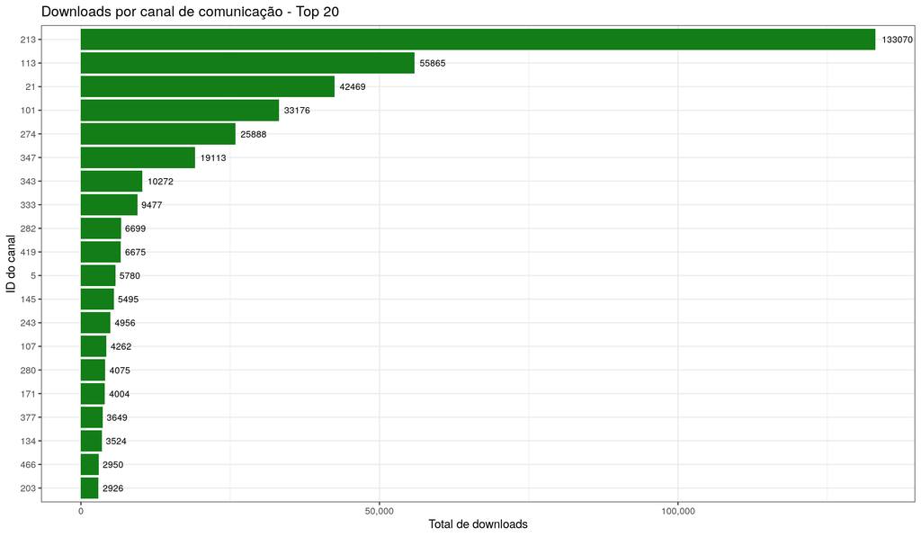

```r
channel_downloads <- download_info[, .(downloads = .N), by = channel]
channel_downloads[, channel := as.factor(channel)]

ggplot(data = channel_downloads[order(-downloads)][1:20]) +
  geom_bar(mapping = aes(x = reorder(channel, downloads), y = downloads),
           fill = '#137d17', stat = 'identity', position = 'dodge') +
  geom_text(mapping = aes(x = reorder(channel, downloads),
                          y = downloads, label = downloads),
           hjust = -0.2, size = 3, position = position_dodge(width = 1),
           inherit.aes = T) +
  scale_y_continuous(labels = comma) + coord_flip() +
  ylab('Total de downloads') + xlab('ID do canal') +
  theme_bw() + ggtitle('Downloads por canal de comunicação - Top 20')
```

## Downloads por intervalos temporais

A partir do momento do clique, podemos buscar padrões comportamentais dos usuários ao longo do tempo

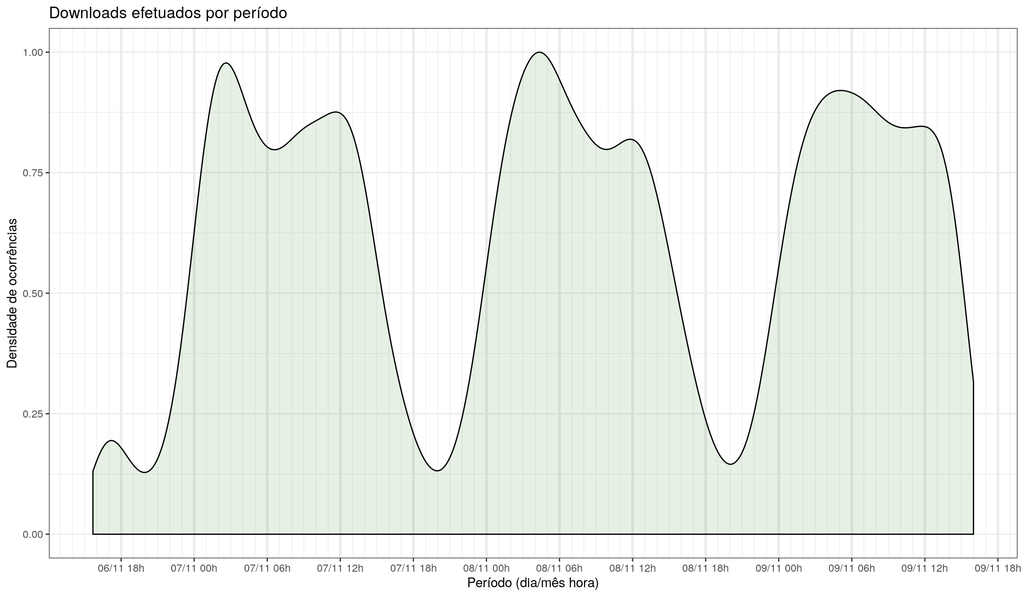

```r
ggplot(data = download_info) +
  geom_density(mapping = aes(x = as_datetime(click_time), y = ..scaled..),
               alpha = 0.1, fill = '#0e7305') +
  scale_x_datetime(name = 'Período (dia/mês hora)',
                   date_breaks = '6 hours', date_labels = format('%d/%m %Hh'),
                   date_minor_breaks = '1 hour') +
  ylab('Densidade de ocorrências') + ggtitle('Downloads efetuados por período') +
  theme_bw() + theme(panel.grid.major.x = element_line(size = 1))
```

Percebemos um padrão semelhante entre os dias observados. A maioria dos downloads ocorreram de cliques realizados entre 00h e 14h.